# Load the data

```python
import pandas
import numpy
import sys
%matplotlib inline
import matplotlib.pyplot as plt
from pandas.tools.plotting import scatter_matrix
import seaborn as sns
import numpy as np
import time
from sklearn import metrics
from sklearn import cross_validation
from sklearn.metrics import classification_report
from sklearn.metrics import confusion_matrix, roc_curve, auc
from sklearn.metrics import accuracy_score
from sklearn.tree import DecisionTreeClassifier
from sklearn.neighbors import KNeighborsClassifier
from sklearn.discriminant_analysis import LinearDiscriminantAnalysis
from sklearn.naive_bayes import GaussianNB
from sklearn.svm import SVC
from IPython.display import set_matplotlib_formats
set_matplotlib_formats('png', 'pdf')
# fix random seed for reproducibility
plt.rcParams['figure.figsize'] = (15, 6)
```

Attribute Information:

4. Mg: Magnesium
5. Al: Aluminum
6. Si: Silicon
7. K: Potassium
8. Ca: Calcium
9. Ba: Barium
   1. Fe: Iron
   2. Type of glass: (class attribute) -- 1 building_windows_float_processed -- 2 building_windows_non_float_processed -- 3 vehicle_windows_float_processed -- 4 vehicle_windows_non_float_processed (none in this database) -- 5 containers -- 6 tableware -- 7 headlamps

```python
# fix random seed for reproducibility
seed = 7
numpy.random.seed(seed)
plt.rcParams['figure.figsize'] = (15, 6)
url = "https://archive.ics.uci.edu/ml/machine-learning-databases/glass/glass.data"
names=['Id', 'refractive index', 'Sodium', 'Magnesium', 'Aluminum',
      'Silicon','Potassium', 'Calcium', 'Barium', 'Iron', 'Type']
data = pandas.read_csv('glass.data.txt',  names = names)
```

```python
shape = data.shape
print(shape)
```

```
(214, 11)
```

```python
types = data.dtypes
print(types)
```

```
Id                    int64
refractive index    float64
Sodium              float64
Magnesium           float64
Aluminum            float64
Silicon             float64
Potassium           float64
Calcium             float64
Barium              float64
Iron                float64
Type                  int64
dtype: object
```

```python
data.head()
```

|  | Id | refractive index | Sodium | Magnesium | Aluminum | Silicon | Potassium | Calcium | Barium | Iron | Type |
| --- | --- | --- | --- | --- | --- | --- | --- | --- | --- | --- | --- |
| 0 | 1 | 1.52101 | 13.64 | 4.49 | 1.10 | 71.78 | 0.06 | 8.75 | 0.0 | 0.0 | 1 |
| 1 | 2 | 1.51761 | 13.89 | 3.60 | 1.36 | 72.73 | 0.48 | 7.83 | 0.0 | 0.0 | 1 |
| 2 | 3 | 1.51618 | 13.53 | 3.55 | 1.54 | 72.99 | 0.39 | 7.78 | 0.0 | 0.0 | 1 |
| 3 | 4 | 1.51766 | 13.21 | 3.69 | 1.29 | 72.61 | 0.57 | 8.22 | 0.0 | 0.0 | 1 |
| 4 | 5 | 1.51742 | 13.27 | 3.62 | 1.24 | 73.08 | 0.55 | 8.07 | 0.0 | 0.0 | 1 |

```python
# Delete Id as has no pattren
del data["Id"]
```

```python
data.tail()
```

|  | refractive index | Sodium | Magnesium | Aluminum | Silicon | Potassium | Calcium | Barium | Iron | Type |
| --- | --- | --- | --- | --- | --- | --- | --- | --- | --- | --- |
| 209 | 1.51623 | 14.14 | 0.0 | 2.88 | 72.61 | 0.08 | 9.18 | 1.06 | 0.0 | 7 |
| 210 | 1.51685 | 14.92 | 0.0 | 1.99 | 73.06 | 0.00 | 8.40 | 1.59 | 0.0 | 7 |
| 211 | 1.52065 | 14.36 | 0.0 | 2.02 | 73.42 | 0.00 | 8.44 | 1.64 | 0.0 | 7 |
| 212 | 1.51651 | 14.38 | 0.0 | 1.94 | 73.61 | 0.00 | 8.48 | 1.57 | 0.0 | 7 |
| 213 | 1.51711 | 14.23 | 0.0 | 2.08 | 73.36 | 0.00 | 8.62 | 1.67 | 0.0 | 7 |

```python
pandas.set_option('display.width', 100)
pandas.set_option('precision', 3)
description = data.describe()
print(description)
```

```
       refractive index   Sodium  Magnesium  Aluminum  Silicon  Potassium  Calcium   Barium  \
count           214.000  214.000    214.000   214.000  214.000    214.000  214.000  214.000
mean              1.518   13.408      2.685     1.445   72.651      0.497    8.957    0.175
std               0.003    0.817      1.442     0.499    0.775      0.652    1.423    0.497
min               1.511   10.730      0.000     0.290   69.810      0.000    5.430    0.000
25%               1.517   12.908      2.115     1.190   72.280      0.122    8.240    0.000
50%               1.518   13.300      3.480     1.360   72.790      0.555    8.600    0.000
75%               1.519   13.825      3.600     1.630   73.088      0.610    9.172    0.000
max               1.534   17.380      4.490     3.500   75.410      6.210   16.190    3.150

          Iron     Type
count  214.000  214.000
mean     0.057    2.780
std      0.097    2.104
min      0.000    1.000
25%      0.000    1.000
50%      0.000    2.000
75%      0.100    3.000
max      0.510    7.000
```

```python
class_counts = data.groupby('Type').size()
print(class_counts)
```

```
Type
1    70
2    76
3    17
5    13
6     9
7    29
dtype: int64
```

```python
correlations = data.corr(method='pearson')
print(correlations)
```

```
                  refractive index  Sodium  Magnesium  Aluminum  Silicon  Potassium    Calcium  \
refractive index         1.000e+00  -0.192     -0.122    -0.407   -0.542     -0.290  8.104e-01
Sodium                  -1.919e-01   1.000     -0.274     0.157   -0.070     -0.266 -2.754e-01
Magnesium               -1.223e-01  -0.274      1.000    -0.482   -0.166      0.005 -4.438e-01
Aluminum                -4.073e-01   0.157     -0.482     1.000   -0.006      0.326 -2.596e-01
Silicon                 -5.421e-01  -0.070     -0.166    -0.006    1.000     -0.193 -2.087e-01
Potassium               -2.898e-01  -0.266      0.005     0.326   -0.193      1.000 -3.178e-01
Calcium                  8.104e-01  -0.275     -0.444    -0.260   -0.209     -0.318  1.000e+00
Barium                  -3.860e-04   0.327     -0.492     0.479   -0.102     -0.043 -1.128e-01
Iron                     1.430e-01  -0.241      0.083    -0.074   -0.094     -0.008  1.250e-01
Type                    -1.642e-01   0.503     -0.745     0.599    0.152     -0.010  9.522e-04

                     Barium   Iron       Type
refractive index -3.860e-04  0.143 -1.642e-01
Sodium            3.266e-01 -0.241  5.029e-01
Magnesium        -4.923e-01  0.083 -7.450e-01
Aluminum          4.794e-01 -0.074  5.988e-01
Silicon          -1.022e-01 -0.094  1.516e-01
Potassium        -4.262e-02 -0.008 -1.005e-02
Calcium          -1.128e-01  0.125  9.522e-04
Barium            1.000e+00 -0.059  5.752e-01
Iron             -5.869e-02  1.000 -1.883e-01
Type              5.752e-01 -0.188  1.000e+00
```

```python
skew = data.skew()
print(skew)
```

```
refractive index    1.625
Sodium              0.454
Magnesium          -1.153
Aluminum            0.907
Silicon            -0.730
Potassium           6.552
Calcium             2.047
Barium              3.416
Iron                1.754
Type                1.115
dtype: float64
```

# Visulize the data

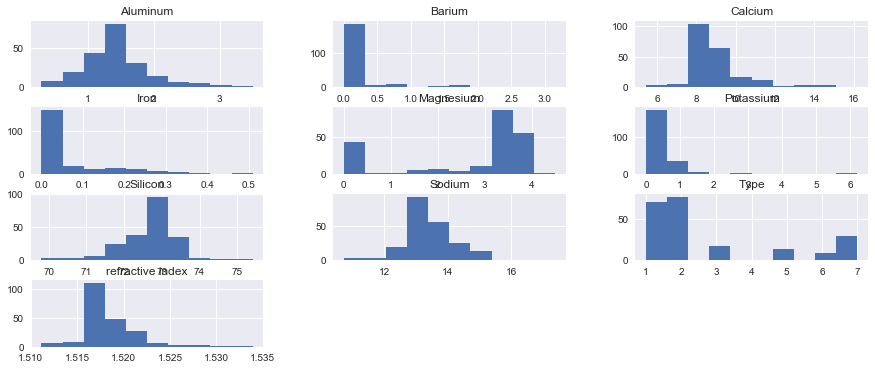

```python
data.hist()
plt.show()
```

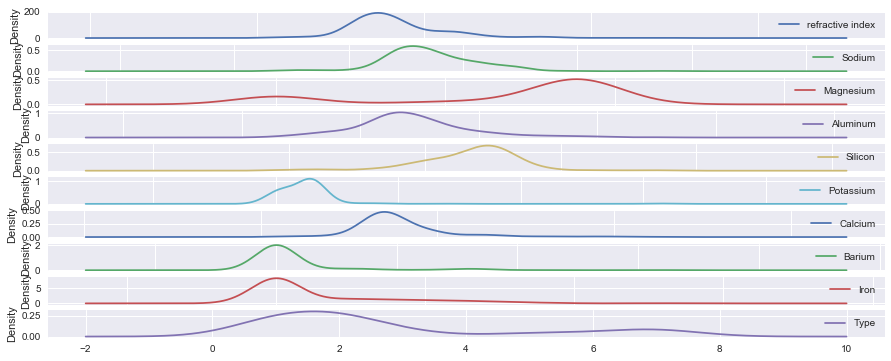

```python
data.plot(kind='density', subplots=True,  sharex=False)
plt.show()
```

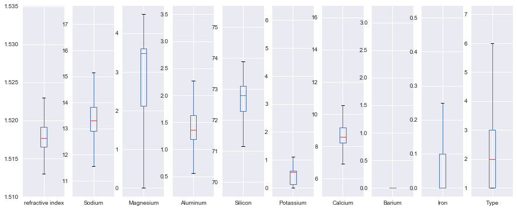

```python
data.plot(kind='box', subplots=True,  sharex=False, sharey=False)
plt.show()
```

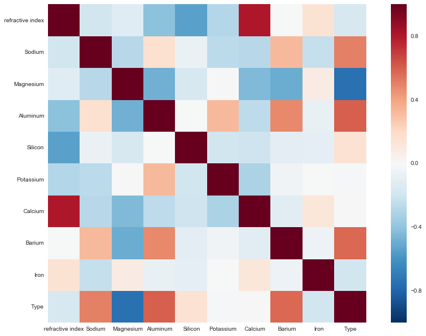

```python
# Encode the categorical features as numbers
def number_encode_features(df):
    result = df.copy()
    encoders = {}
    for column in result.columns:
        if result.dtypes[column] == np.object:
            encoders[column] = preprocessing.LabelEncoder()
            result[column] = encoders[column].fit_transform(result[column])
    return result, encoders

# Calculate the correlation and plot it
plt.rcParams['figure.figsize'] = (15, 10)
encoded_data, _ = number_encode_features(data)
sns.heatmap(encoded_data.corr(), square=True)
plt.show()
```

```python
data[["Calcium", "refractive index"]].head(20)
```

|  | Calcium | refractive index |
| --- | --- | --- |
| 0 | 8.75 | 1.521 |
| 1 | 7.83 | 1.518 |
| 2 | 7.78 | 1.516 |
| 3 | 8.22 | 1.518 |
| 4 | 8.07 | 1.517 |
| 5 | 8.07 | 1.516 |
| 6 | 8.17 | 1.517 |
| 7 | 8.24 | 1.518 |
| 8 | 8.30 | 1.519 |
| 9 | 8.40 | 1.518 |
| 10 | 8.09 | 1.516 |
| 11 | 8.56 | 1.518 |
| 12 | 8.05 | 1.516 |
| 13 | 8.38 | 1.517 |
| 14 | 8.50 | 1.518 |
| 15 | 8.39 | 1.518 |
| 16 | 8.70 | 1.518 |
| 17 | 9.15 | 1.522 |
| 18 | 8.89 | 1.519 |
| 19 | 8.44 | 1.517 |

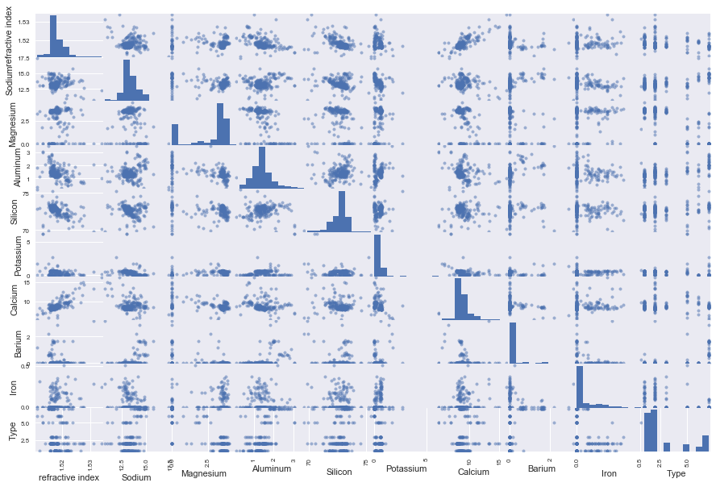

```python
scatter_matrix(data)
plt.show()
```

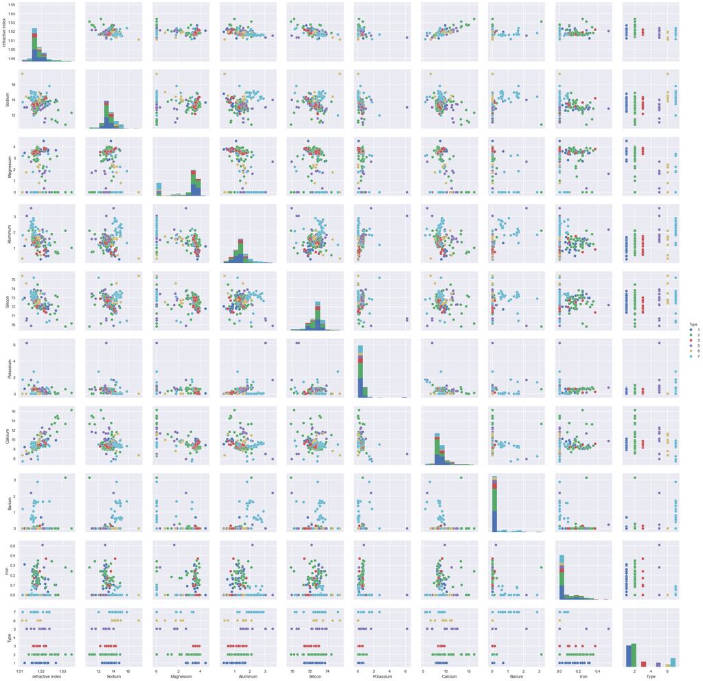

```python
import seaborn as sns
sns.pairplot(data, hue='Type')
```

# Prepare the data for classification

```python
from sklearn import preprocessing
# for training data
dataset = data.values
X = dataset[:,0:9].astype(float)
Y = dataset[:,9]
features = preprocessing.scale(X)
target = Y
```

```python
# Make developement dataset for genrilization and final testing
from sklearn.cross_validation import train_test_split
# Extracting 20% testing data
X_train_feature, X_deploy, y_train_feature, y_deploy = train_test_split(
    features, target, test_size=0.20, random_state=0)
# Make training and validation data sets for building the models and choose the hyperparameters
X_train, X_test, y_train, y_test = train_test_split(
    X_train_feature, y_train_feature, test_size=0.20, random_state=0)
print('Number of training examples',len(X_train))
print('Number of validation examples',len(X_test))
print('Number of testing examples',len(X_deploy))
```

```
Number of training examples 136
Number of validation examples 35
Number of testing examples 43
```

## Preproccing

```python
from sklearn import preprocessing
# normalize the data attributes
X_train = preprocessing.normalize(X_train)
X_test = preprocessing.normalize(X_test)
X_deploy = preprocessing.normalize(X_deploy)
# standardize the data attributes
X_train = preprocessing.scale(X_train)
X_test = preprocessing.scale(X_test)
X_deploy = preprocessing.scale(X_deploy)
```

# Feature Selection

```python
from sklearn import metrics
from sklearn.ensemble import ExtraTreesClassifier
model = ExtraTreesClassifier()
model.fit(X_train, y_train)
# display the relative importance of each attribute
print(model.feature_importances_)
```

```
[ 0.08350701  0.09380749  0.15477119  0.15731787  0.06764301  0.08284958
  0.14041725  0.16205469  0.05763192]
```

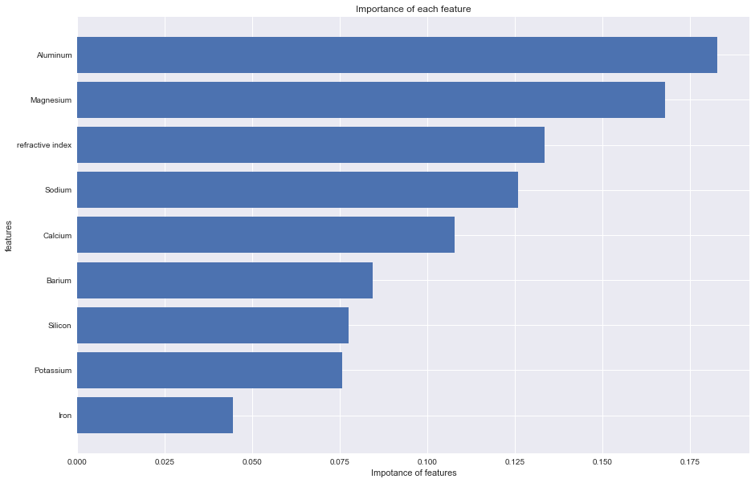

```python
# importabt of features according to random forest
from sklearn.ensemble import RandomForestClassifier
rf = RandomForestClassifier(n_estimators = 15)
rf.fit(X, Y)
imp = rf.feature_importances_
names = data.columns

imp, names = zip(*sorted(zip(imp,names)))
plt.barh(range(len(names)), imp, align = 'center')
plt.yticks(range(len(names)), names)

plt.xlabel('Impotance of features')
plt.ylabel('features')
plt.title('Importance of each feature')
plt.show()
```

# Building classifiers

## KNN classifier

It turns out that k=5 is the best choose of k on the validation set

```python
from sklearn.neighbors import KNeighborsClassifier
clf_neigh = KNeighborsClassifier(n_neighbors=5)
#Training
start_time = time.time()
clf_neigh.fit(X_train, y_train)
print("The time for training KNN is  %s seconds " % (time.time() - start_time))

# Make a prediction
y_pred = clf_neigh.predict(X_test)

print("\n===================================================================")
print("The accuracy on validation dataset of Knn : \t", metrics.accuracy_score(y_test, y_pred))
print("===================================================================")
print(metrics.classification_report(y_test, y_pred, target_names=['1' , '2' , '3' , '5' , '6' , '7']))
```

```
The time for training KNN is  0.0007297992706298828 seconds

===================================================================
The accuracy on validation dataset of Knn : 	 0.714285714286
===================================================================
             precision    recall  f1-score   support

          1       0.88      0.79      0.83        19
          2       0.50      0.83      0.62         6
          3       0.00      0.00      0.00         2
          5       0.00      0.00      0.00         1
          6       1.00      0.33      0.50         3
          7       0.80      1.00      0.89         4

avg / total       0.74      0.71      0.70        35
```

## SVM classifier

### Linear SVM "LinearSVC"

It turns out that C=20 is the best on the validation set

```python
from sklearn.svm import LinearSVC
clf_svm_linear = LinearSVC(C=20.0)
#Training
start_time = time.time()
clf_svm_linear.fit(X_train, y_train)
print("The time for training SVM is  %s seconds " % (time.time() - start_time))

# Make a prediction
y_pred = clf_svm_linear.predict(X_test)

print("\n===================================================================")
print("The accuracy on validation dataset of Linear SVM : \t", metrics.accuracy_score(y_test, y_pred))
print("===================================================================")
print(metrics.classification_report(y_test, y_pred, target_names=['1' , '2' , '3' , '5' , '6' , '7']))
```

```
The time for training SVM is  0.01297616958618164 seconds

===================================================================
The accuracy on validation dataset of Linear SVM : 	 0.657142857143
===================================================================
             precision    recall  f1-score   support

          1       0.81      0.68      0.74        19
          2       0.33      0.50      0.40         6
          3       0.00      0.00      0.00         2
          5       0.00      0.00      0.00         1
          6       1.00      1.00      1.00         3
          7       0.80      1.00      0.89         4

avg / total       0.68      0.66      0.66        35
```

### SVM "SVC" with kernel='rbf'

It turns out that C=5 is the best on the validation set

```python
from sklearn.svm import SVC
clf_svm = SVC(C=5.0, kernel='rbf')
#Training
start_time = time.time()
clf_svm.fit(X_train, y_train)
print("The time for training SVM is  %s seconds " % (time.time() - start_time))

# Make a prediction
y_pred = clf_svm.predict(X_test)

print("\n===================================================================")
print("The accuracy on validation dataset of SVM : \t", metrics.accuracy_score(y_test, y_pred))
print("===================================================================")
print(metrics.classification_report(y_test, y_pred, target_names=['1' , '2' , '3' , '5' , '6' , '7']))
```

```
The time for training SVM is  0.0019328594207763672 seconds

===================================================================
The accuracy on validation dataset of SVM : 	 0.657142857143
===================================================================
             precision    recall  f1-score   support

          1       0.80      0.63      0.71        19
          2       0.45      0.83      0.59         6
          3       0.00      0.00      0.00         2
          5       0.00      0.00      0.00         1
          6       1.00      0.67      0.80         3
          7       0.80      1.00      0.89         4

avg / total       0.69      0.66      0.65        35
```

## Decsion Tree classifier

### DT with Gini impurity "gini", CART (Classification and Regression Trees)

It turns out that min_samples_split=2 is the best on the validation set

```python
# CART tree
from sklearn.tree import DecisionTreeClassifier
clf_dt = DecisionTreeClassifier(min_samples_split=2)
#Training
start_time = time.time()
clf_dt.fit(X_train, y_train)
print("The time for training Decision Tree is  %s seconds " % (time.time() - start_time))

# Make a prediction
y_pred = clf_dt.predict(X_test)

print("\n===================================================================")
print("The accuracy on validation dataset of DT gini (CART) : \t", metrics.accuracy_score(y_test, y_pred))
print("===================================================================")
print(metrics.classification_report(y_test, y_pred, target_names=['1' , '2' , '3' , '5' , '6' , '7']))
```

```
The time for training Decision Tree is  0.0011987686157226562 seconds

===================================================================
The accuracy on validation dataset of DT gini (CART) : 	 0.571428571429
===================================================================
             precision    recall  f1-score   support

          1       0.82      0.47      0.60        19
          2       0.31      0.83      0.45         6
          3       0.00      0.00      0.00         2
          5       0.00      0.00      0.00         1
          6       1.00      0.67      0.80         3
          7       0.80      1.00      0.89         4

avg / total       0.67      0.57      0.57        35
```

### DT with “entropy” for the information gain, C4.5 (aka J48 is an open source Java Weka) and C5.0

It turns out that min_samples_split=2 is the best on the validation set

```python
# Here I use C5.0 tree as its more accurate that C4.5 and more recent.
from sklearn.tree import DecisionTreeClassifier
clf_dt_IG = DecisionTreeClassifier(criterion='entropy', min_samples_split=2)
#Training
start_time = time.time()
clf_dt_IG.fit(X_train, y_train)
print("The time for training Decision Tree is  %s seconds " % (time.time() - start_time))

# Make a prediction
y_pred = clf_dt_IG.predict(X_test)

print("\n===================================================================")
print("The accuracy on validation dataset of DT ENTORPY : \t", metrics.accuracy_score(y_test, y_pred))
print("===================================================================")
print(metrics.classification_report(y_test, y_pred, target_names=['1' , '2' , '3' , '5' , '6' , '7']))
```

```
The time for training Decision Tree is  0.0015170574188232422 seconds

===================================================================
The accuracy on validation dataset of DT ENTORPY : 	 0.6
===================================================================
             precision    recall  f1-score   support

          1       0.85      0.58      0.69        19
          2       0.33      0.67      0.44         6
          3       0.00      0.00      0.00         2
          5       0.00      0.00      0.00         1
          6       1.00      0.67      0.80         3
          7       0.80      1.00      0.89         4

avg / total       0.69      0.60      0.62        35
```

Ensemble methods

## Bagging Method

### Bagging Method with Knn

Using Best KNN classifier fitted the data, each built on random subsets of 50% of the samples and 50% of the features.

```python
from sklearn.ensemble import BaggingClassifier
from sklearn.neighbors import KNeighborsClassifier
clf_dt_BGKN = BaggingClassifier(KNeighborsClassifier(n_neighbors=5),
                             max_samples=0.5, max_features=0.5)
start_time = time.time()
clf_dt_BGKN.fit(X_train, y_train)
print("The time for training Bagging Knn is  %s seconds " % (time.time() - start_time))

# Make a prediction
y_pred = clf_dt_BGKN.predict(X_test)

print("\n===================================================================")
print("The accuracy on validation dataset of BAGGING Knn : \t", metrics.accuracy_score(y_test, y_pred))
print("===================================================================")
print(metrics.classification_report(y_test, y_pred, target_names=['1' , '2' , '3' , '5' , '6' , '7']))
```

```
The time for training Bagging Knn is  0.009596109390258789 seconds

===================================================================
The accuracy on validation dataset of BAGGING Knn : 	 0.742857142857
===================================================================
             precision    recall  f1-score   support

          1       1.00      0.84      0.91        19
          2       0.50      1.00      0.67         6
          3       0.00      0.00      0.00         2
          5       0.00      0.00      0.00         1
          6       0.00      0.00      0.00         3
          7       0.57      1.00      0.73         4

avg / total       0.69      0.74      0.69        35
```

### Bagging Method with DT

Using Best DT with 'entropy', each built on random subsets of 50% of the samples and 50% of the features.

```python
from sklearn.ensemble import BaggingClassifier
from sklearn.tree import DecisionTreeClassifier
clf_dt_BGDT = BaggingClassifier(DecisionTreeClassifier(criterion='entropy', min_samples_split=2),
                             max_samples=0.5, max_features=0.5)
start_time = time.time()
clf_dt_BGDT.fit(X_train, y_train)
print("The time for training Bagging DT is  %s seconds " % (time.time() - start_time))

# Make a prediction
y_pred = clf_dt_BGDT.predict(X_test)

print("\n===================================================================")
print("The accuracy on validation dataset of BAGGING DT ENTORPY : \t", metrics.accuracy_score(y_test, y_pred))
print("===================================================================")
print(metrics.classification_report(y_test, y_pred, target_names=['1' , '2' , '3' , '5' , '6' , '7']))
```

```
The time for training Bagging DT is  0.013501882553100586 seconds

===================================================================
The accuracy on validation dataset of BAGGING DT ENTORPY : 	 0.6
===================================================================
             precision    recall  f1-score   support

          1       0.85      0.58      0.69        19
          2       0.33      0.83      0.48         6
          3       0.00      0.00      0.00         2
          5       0.00      0.00      0.00         1
          6       1.00      0.33      0.50         3
          7       0.80      1.00      0.89         4

avg / total       0.69      0.60      0.60        35
```

## Random Forest

DT with 'gini'

```python
from sklearn.ensemble import RandomForestClassifier
clf_dt_RF = RandomForestClassifier()
#Training
start_time = time.time()
clf_dt_RF.fit(X_train, y_train)
print("The time for training Decision Tree is  %s seconds " % (time.time() - start_time))

# Make a prediction
y_pred = clf_dt_RF.predict(X_test)

print("\n===================================================================")
print("The accuracy on validation dataset of RANDOM FOREST DT : \t", metrics.accuracy_score(y_test, y_pred))
print("===================================================================")
print(metrics.classification_report(y_test, y_pred, target_names=['1' , '2' , '3' , '5' , '6' , '7']))
```

```
The time for training Decision Tree is  0.013896942138671875 seconds

===================================================================
The accuracy on validation dataset of RANDOM FOREST DT : 	 0.628571428571
===================================================================
             precision    recall  f1-score   support

          1       0.92      0.58      0.71        19
          2       0.38      0.83      0.53         6
          3       0.50      0.50      0.50         2
          5       0.00      0.00      0.00         1
          6       1.00      0.33      0.50         3
          7       0.67      1.00      0.80         4

avg / total       0.75      0.63      0.64        35
```

### Ada Boost

DT with 'gini'

```python
from sklearn.ensemble import AdaBoostClassifier
clf_dt_AD = AdaBoostClassifier()
#Training
start_time = time.time()
clf_dt_AD.fit(X_train, y_train)
print("The time for training Decision Tree is  %s seconds " % (time.time() - start_time))

# Make a prediction
y_pred = clf_dt_AD.predict(X_test)

print("\n===================================================================")
print("The accuracy on validation dataset of ADA BOOST DT GINI : \t", metrics.accuracy_score(y_test, y_pred))
print("===================================================================")
print(metrics.classification_report(y_test, y_pred, target_names=['1' , '2' , '3' , '5' , '6' , '7']))
```

```
The time for training Decision Tree is  0.06886911392211914 seconds

===================================================================
The accuracy on validation dataset of ADA BOOST DT GINI : 	 0.285714285714
===================================================================
             precision    recall  f1-score   support

          1       0.00      0.00      0.00        19
          2       0.20      1.00      0.33         6
          3       0.00      0.00      0.00         2
          5       0.00      0.00      0.00         1
          6       0.00      0.00      0.00         3
          7       0.80      1.00      0.89         4

avg / total       0.13      0.29      0.16        35
```

## Naive Bayes methods

```python
from sklearn.naive_bayes import GaussianNB
clf_NB = GaussianNB()
#Training
start_time = time.time()
clf_NB.fit(X_train, y_train)
print("The time for training Naive Bayes is  %s seconds " % (time.time() - start_time))

# Make a prediction
y_pred = clf_NB.predict(X_test)

print("\n===================================================================")
print("The accuracy on validation dataset of NB : \t", metrics.accuracy_score(y_test, y_pred))
print("===================================================================")
print(metrics.classification_report(y_test, y_pred, target_names=['1' , '2' , '3' , '5' , '6' , '7']))
```

```
The time for training Naive Bayes is  0.0015752315521240234 seconds

===================================================================
The accuracy on validation dataset of NB : 	 0.714285714286
===================================================================
             precision    recall  f1-score   support

          1       0.88      0.74      0.80        19
          2       0.44      0.67      0.53         6
          3       0.00      0.00      0.00         2
          5       0.00      0.00      0.00         1
          6       1.00      1.00      1.00         3
          7       0.80      1.00      0.89         4

avg / total       0.73      0.71      0.71        35
```

## Linear Discriminant Analysis classifier

```python
from sklearn.discriminant_analysis import LinearDiscriminantAnalysis
clf_dt_LDA = LinearDiscriminantAnalysis()
#Training
start_time = time.time()
clf_dt_LDA.fit(X_train, y_train)
print("The time for training Decision Tree is  %s seconds " % (time.time() - start_time))

# Make a prediction
y_pred = clf_dt_LDA.predict(X_test)

print("\n===================================================================")
print("The accuracy on validation dataset of LDA : \t", metrics.accuracy_score(y_test, y_pred))
print("===================================================================")
print(metrics.classification_report(y_test, y_pred, target_names=['1' , '2' , '3' , '5' , '6' , '7']))
```

```
The time for training Decision Tree is  0.0019259452819824219 seconds

===================================================================
The accuracy on validation dataset of LDA : 	 0.657142857143
===================================================================
             precision    recall  f1-score   support

          1       0.80      0.63      0.71        19
          2       0.36      0.67      0.47         6
          3       1.00      0.50      0.67         2
          5       0.00      0.00      0.00         1
          6       1.00      0.67      0.80         3
          7       0.80      1.00      0.89         4

avg / total       0.73      0.66      0.67        35
```

## Quadratic Discriminant Analysis classifier

```python
from sklearn.discriminant_analysis import QuadraticDiscriminantAnalysis
clf_dt_QDA = QuadraticDiscriminantAnalysis()
#Training
start_time = time.time()
clf_dt_QDA.fit(X_train, y_train)
print("The time for training Decision Tree is  %s seconds " % (time.time() - start_time))

# Make a prediction
y_pred = clf_dt_QDA.predict(X_test)

print("\n===================================================================")
print("The accuracy on validation dataset of QDA : \t", metrics.accuracy_score(y_test, y_pred))
print("===================================================================")
print(metrics.classification_report(y_test, y_pred, target_names=['1' , '2' , '3' , '5' , '6' , '7']))
```

```
The time for training Decision Tree is  0.004348039627075195 seconds

===================================================================
The accuracy on validation dataset of QDA : 	 0.542857142857
===================================================================
             precision    recall  f1-score   support

          1       0.77      0.53      0.62        19
          2       0.35      1.00      0.52         6
          3       0.00      0.00      0.00         2
          5       0.00      0.00      0.00         1
          6       0.00      0.00      0.00         3
          7       0.60      0.75      0.67         4

avg / total       0.55      0.54      0.50        35
```

## Logistic Regression

```python
from sklearn.linear_model import LogisticRegression
LogReg = LogisticRegression(C=1e5)
#Training
start_time = time.time()
LogReg.fit(X_train, y_train)
print("The time for training LDA is  %s seconds " % (time.time() - start_time))

# Make a prediction
y_pred = LogReg.predict(X_test)

print("\n===================================================================")
print("The accuracy on validation dataset of LOGISTIC REGRESSION : \t", metrics.accuracy_score(y_test, y_pred))
print("===================================================================")
print(metrics.classification_report(y_test, y_pred, target_names=['1' , '2' , '3' , '5' , '6' , '7']))
```

```
The time for training LDA is  0.003370046615600586 seconds

===================================================================
The accuracy on validation dataset of LOGISTIC REGRESSION : 	 0.6
===================================================================
             precision    recall  f1-score   support

          1       0.80      0.63      0.71        19
          2       0.33      0.50      0.40         6
          3       0.00      0.00      0.00         2
          5       0.00      0.00      0.00         1
          6       1.00      0.67      0.80         3
          7       0.57      1.00      0.73         4

avg / total       0.64      0.60      0.60        35
```

## Gaussian Process Classifier

```python
from sklearn.gaussian_process import GaussianProcessClassifier
GP = GaussianProcessClassifier()
#Training
start_time = time.time()
GP.fit(X_train, y_train)
print("The time for training QDA is  %s seconds " % (time.time() - start_time))

# Make a prediction
y_pred = GP.predict(X_test)

print("\n===================================================================")
print("The accuracy on validation dataset of GP CLASSSIFIER : \t", metrics.accuracy_score(y_test, y_pred))
print("===================================================================")
print(metrics.classification_report(y_test, y_pred, target_names=['1' , '2' , '3' , '5' , '6' , '7']))
```

```
The time for training QDA is  0.06183290481567383 seconds

===================================================================
The accuracy on validation dataset of GP CLASSSIFIER : 	 0.771428571429
===================================================================
             precision    recall  f1-score   support

          1       0.88      0.79      0.83        19
          2       0.56      0.83      0.67         6
          3       0.00      0.00      0.00         2
          5       0.00      0.00      0.00         1
          6       1.00      1.00      1.00         3
          7       0.80      1.00      0.89         4

avg / total       0.75      0.77      0.75        35
```

## LightGBM, Light Gradient Boosting Machine

```python
import lightgbm as lgb
lgb_train = lgb.Dataset(X_train, y_train)
gbm = lgb.LGBMClassifier()
gbm.fit(X_train, y_train, eval_metric="multi_logloss")
y_pred = gbm.predict(X_test)


print("\n===================================================================")
print("The accuracy on validation dataset of LIGHTGBM : \t", metrics.accuracy_score(y_test, y_pred))
print("===================================================================")
print(metrics.classification_report(y_test, y_pred, target_names=['1' , '2' , '3' , '5' , '6' , '7']))
```

```
===================================================================
The accuracy on validation dataset of LIGHTGBM : 	 0.628571428571
===================================================================
             precision    recall  f1-score   support

          1       0.86      0.63      0.73        19
          2       0.36      0.83      0.50         6
          3       0.00      0.00      0.00         2
          5       0.00      0.00      0.00         1
          6       1.00      0.33      0.50         3
          7       0.80      1.00      0.89         4

avg / total       0.70      0.63      0.62        35
```

## XGBoost, eXtreme Gradient Boosting

```python
import xgboost as xgb
XG_Boost = xgb.XGBClassifier(max_depth=3, n_estimators=300, learning_rate=0.05).fit(X_train, y_train)
y_pred = XG_Boost.predict(X_test)

print("\n===================================================================")
print("The accuracy on validation dataset of XGBOOST : \t", metrics.accuracy_score(y_test, y_pred))
print("===================================================================")
print(metrics.classification_report(y_test, y_pred, target_names=['1' , '2' , '3' , '5' , '6' , '7']))
```

```
===================================================================
The accuracy on validation dataset of XGBOOST : 	 0.714285714286
===================================================================
             precision    recall  f1-score   support

          1       0.88      0.74      0.80        19
          2       0.42      0.83      0.56         6
          3       0.00      0.00      0.00         2
          5       0.00      0.00      0.00         1
          6       1.00      0.67      0.80         3
          7       0.80      1.00      0.89         4

avg / total       0.72      0.71      0.70        35
```

## Neural Networks classifier

```python
import seaborn as sns
import numpy as np
from sklearn.cross_validation import train_test_split
from keras.models import Sequential
from keras.layers import Dense, Dropout
from keras.regularizers import l2

from keras.utils import np_utils

labelsTrain = np_utils.to_categorical(y_train)
labelsTest = np_utils.to_categorical(y_test)
model = Sequential()
model.add(Dense(35,
                input_shape=(9,),
                activation="relu",
                W_regularizer=l2(0.001)))
#model.add(Dropout(0.5))
model.add(Dense(8, activation="softmax"))

model.compile(loss='categorical_crossentropy',
              metrics=['accuracy'],
              optimizer='adam')
# Actual modelling
start_time = time.time()
model.fit(X_train, labelsTrain, verbose=0, batch_size=100, nb_epoch=100)
print("The time for training NN is  %s seconds " % (time.time() - start_time))
score, accuracy = model.evaluate(X_test, labelsTest, batch_size=100, verbose=0)
print("Test fraction correct (NN-Score) = {:.2f}".format(score))
print("Test fraction correct (NN-Accuracy) = {:.2f}".format(accuracy))
```

```
Using Theano backend.
```

```
The time for training NN is  1.1362569332122803 seconds
Test fraction correct (NN-Score) = 1.00
Test fraction correct (NN-Accuracy) = 0.66
```

```python
y_pred = model.predict_classes(X_test)

print("\n===================================================================")
print("The accuracy on validation dataset of Neural Networks : \t", metrics.accuracy_score(y_test, y_pred))
print("===================================================================")
print(metrics.classification_report(y_test, y_pred, target_names=['1' , '2' , '3' , '5' , '6' , '7']))
```

```
===================================================================
The accuracy on validation dataset of Neural Networks : 	 0.657142857143
===================================================================
             precision    recall  f1-score   support

          1       0.83      0.79      0.81        19
          2       0.36      0.67      0.47         6
          3       0.00      0.00      0.00         2
          5       0.00      0.00      0.00         1
          6       0.00      0.00      0.00         3
          7       0.67      1.00      0.80         4

avg / total       0.59      0.66      0.61        35
```

```python
path = './glass/'
sys.path.append("./glass")
model.save_weights('glassModelbest.hdf5',overwrite=True)
```

```python
np.save('./glass/X_train', X_train)
np.save('./glass/y_train', y_train)
np.save('./glass/X_test', X_test)
np.save('./glass/y_test', y_test)
np.save('./glass/X_deploy', X_deploy)
np.save('./glass/y_deploy', y_deploy)
```